# R Notebook

```r
library(ggplot2)
library(palmerpenguins)
head(penguins)
```

| species | island | bill_length_mm | bill_depth_mm | flipper_length_mm | body_mass_g | sex | year |
| --- | --- | --- | --- | --- | --- | --- | --- |
| Adelie | Torgersen | 39.1 | 18.7 | 181 | 3750 | male | 2007 |
| Adelie | Torgersen | 39.5 | 17.4 | 186 | 3800 | female | 2007 |
| Adelie | Torgersen | 40.3 | 18.0 | 195 | 3250 | female | 2007 |
| Adelie | Torgersen | NA | NA | NA | NA | NA | 2007 |
| Adelie | Torgersen | 36.7 | 19.3 | 193 | 3450 | female | 2007 |
| Adelie | Torgersen | 39.3 | 20.6 | 190 | 3650 | male | 2007 |

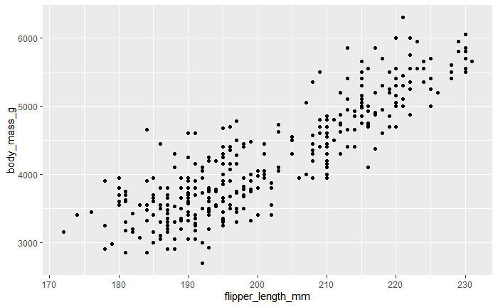

```r
ggplot(data = penguins)+
  geom_point(mapping = aes(x = flipper_length_mm, y = body_mass_g))
```

```r
data("diamonds")
head(diamonds)
```

| carat | cut | color | clarity | depth | table | price | x | y | z |
| --- | --- | --- | --- | --- | --- | --- | --- | --- | --- |
| 0.23 | Ideal | E | SI2 | 61.5 | 55 | 326 | 3.95 | 3.98 | 2.43 |
| 0.21 | Premium | E | SI1 | 59.8 | 61 | 326 | 3.89 | 3.84 | 2.31 |
| 0.23 | Good | E | VS1 | 56.9 | 65 | 327 | 4.05 | 4.07 | 2.31 |
| 0.29 | Premium | I | VS2 | 62.4 | 58 | 334 | 4.20 | 4.23 | 2.63 |
| 0.31 | Good | J | SI2 | 63.3 | 58 | 335 | 4.34 | 4.35 | 2.75 |
| 0.24 | Very Good | J | VVS2 | 62.8 | 57 | 336 | 3.94 | 3.96 | 2.48 |

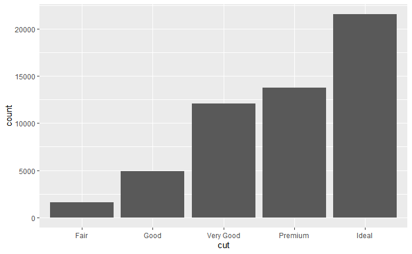

```r
ggplot(data = diamonds)+geom_bar(mapping = aes(x = cut))
```

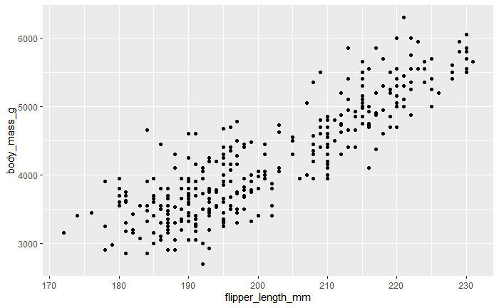

The plot shows a positive relationship between the two variables. In other words, the larger the penguin, the longer the flipper.

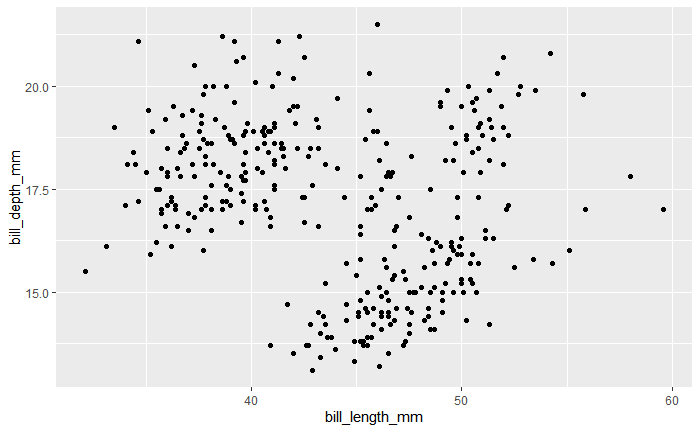

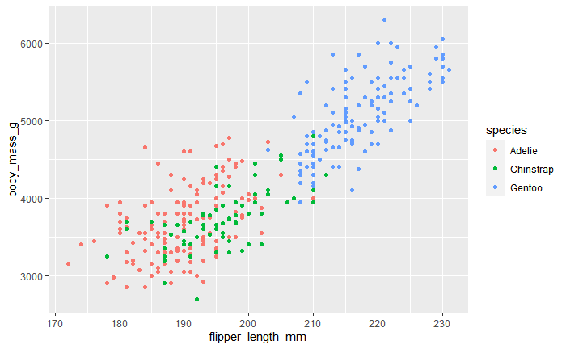

The Gentoo are the largest of the three penguin species. The legend just to the right of the plot shows us that the blue points refer to the Gentoo penguins.

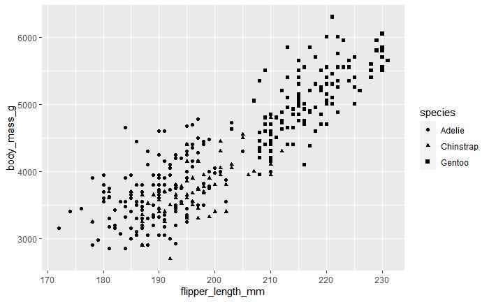

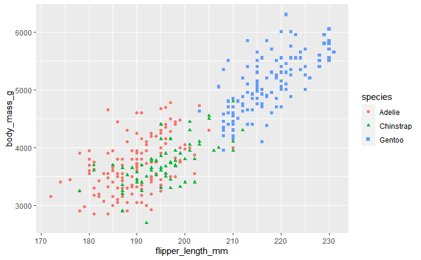

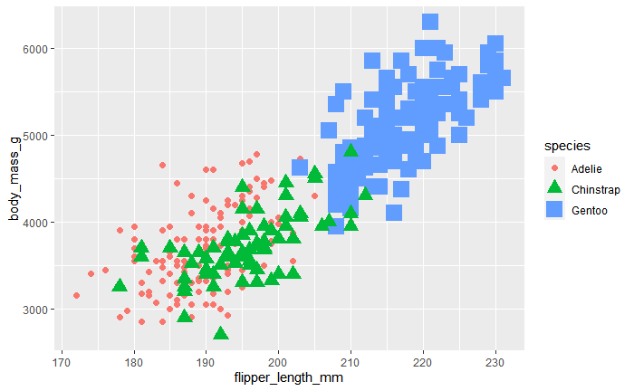

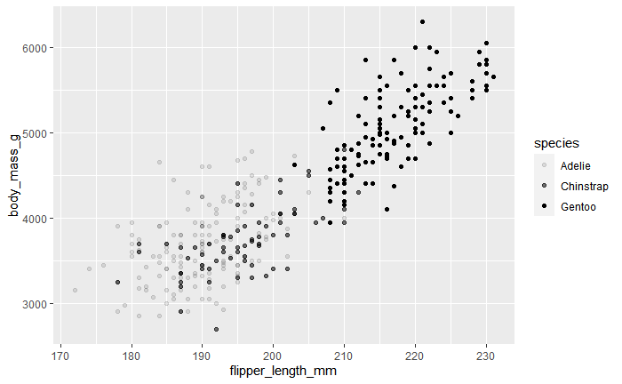

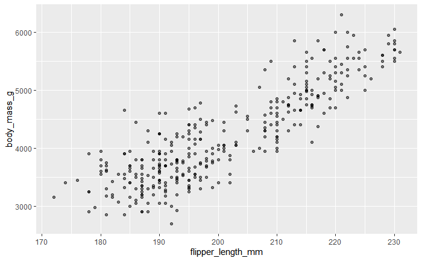

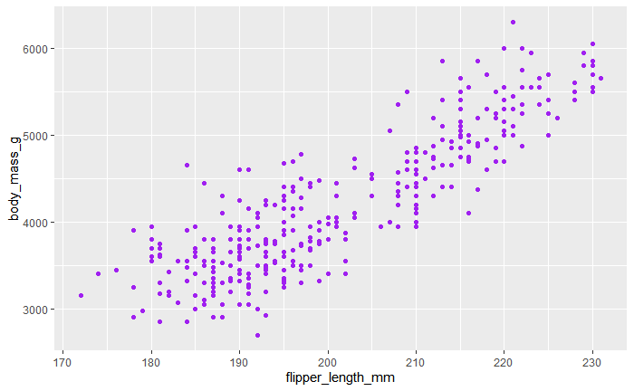

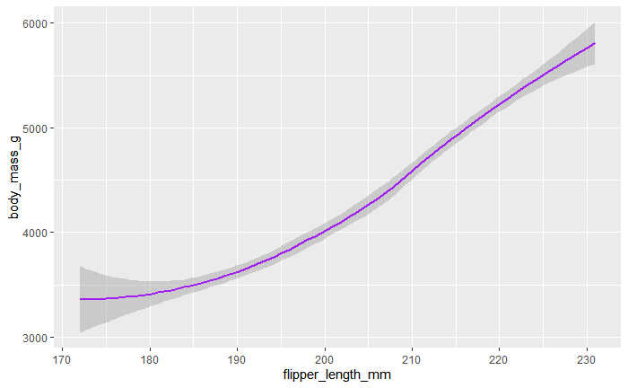

The geom underscore smooth function’s useful for showing general trends in our data. The line clearly shows the positive relationship between body mass and flipper length. The larger the penguin, the longer the flipper. We can even use two geoms in the same plot. Let’s say we want to show the relationship between the trend line and the data points more clearly. We can combine the code for geom underscore point and the code for geom underscore smooth by adding a plus symbol after geom underscore smooth

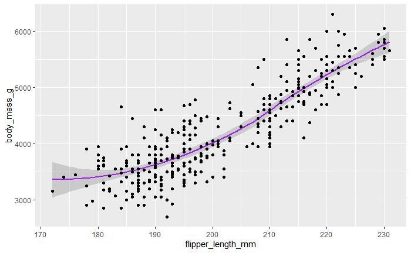

```r
ggplot(data = penguins, aes(x = flipper_length_mm, y = body_mass_g))+
  geom_smooth(color = "purple")+geom_point()
```

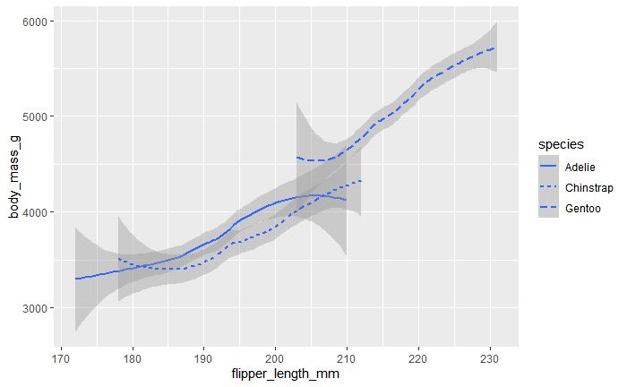

The geom underscore jitter function creates a scatter plot and then adds a small amount of random noise to each point in the plot. Jittering helps us deal with over-plotting, which happens when the data points in a plot overlap with each other. Jittering makes the points easier to find.

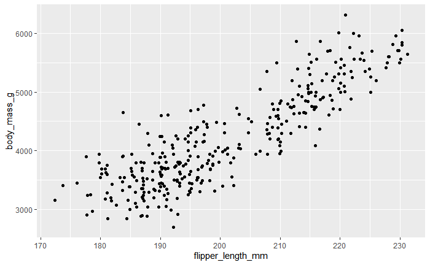

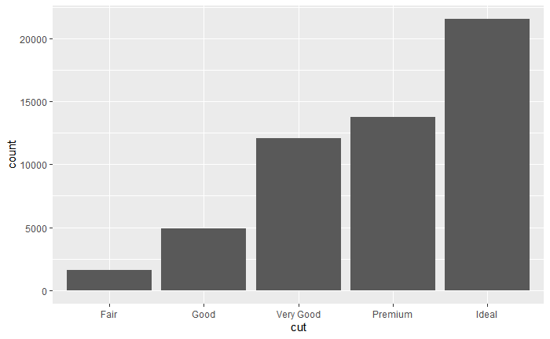

When you use geom underscore bar, R automatically counts how many times each x-value appears in the data, and then shows the counts on the y-axis. The default for geom underscore bar is to count rows.

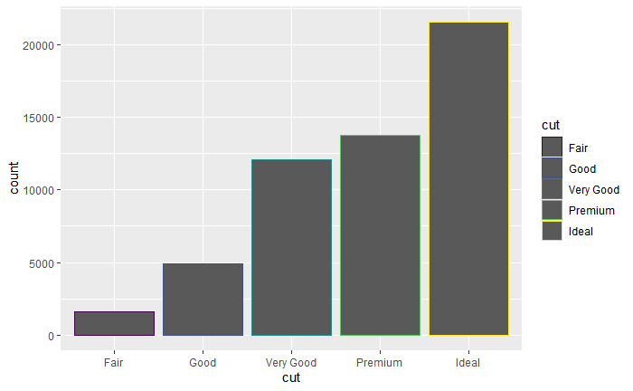

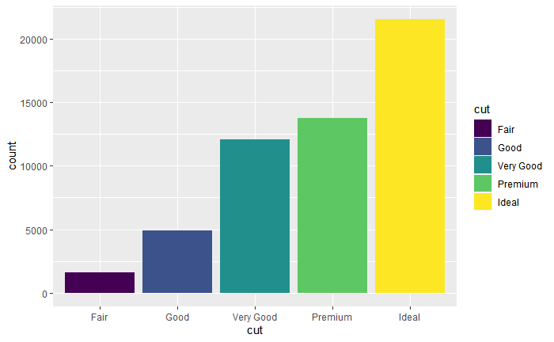

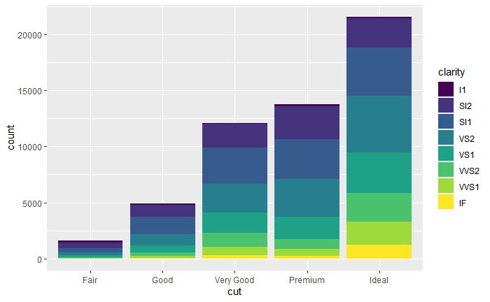

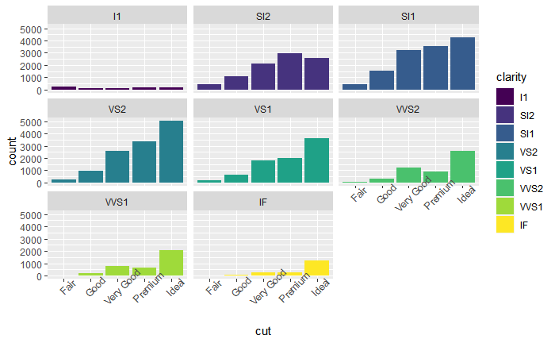

Facet allows you to display smaller groups, or subset of your data facet_wrap for single variable facet_grid for two variables

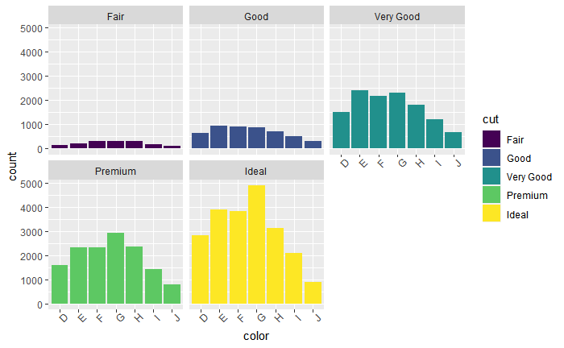

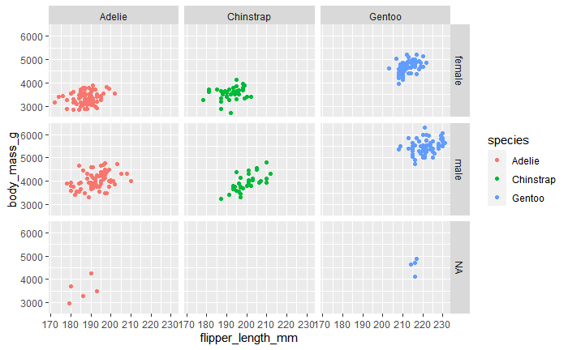

```r
ggplot(data = penguins, aes(x = flipper_length_mm, y = body_mass_g, color = species))+
  geom_point()+facet_grid(~sex~species)
```

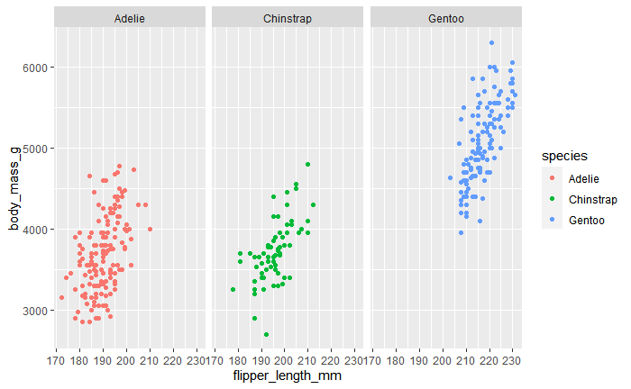

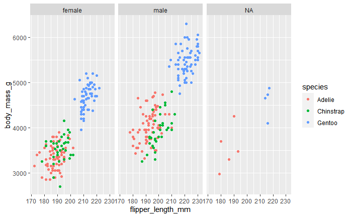

Annotation

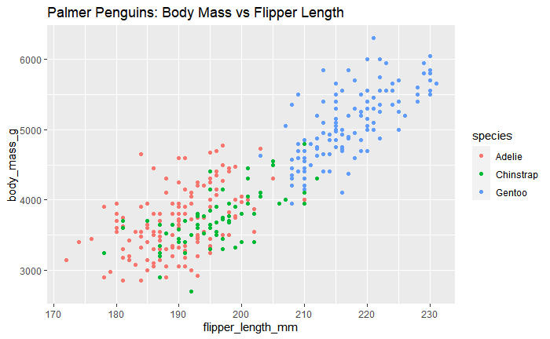

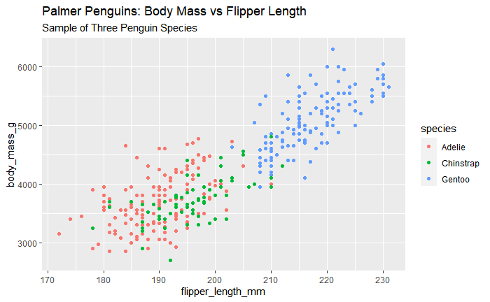

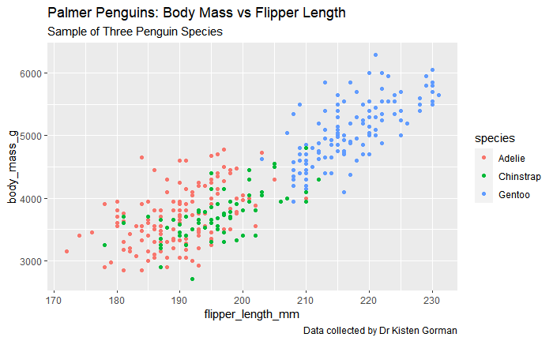

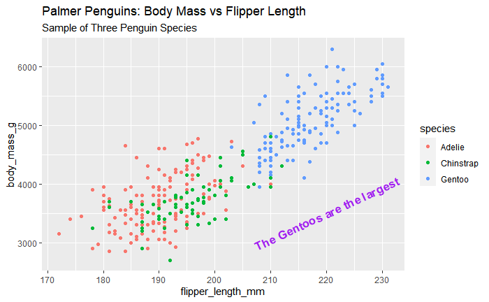

[figure not shown]

```r
ggsave("Three Penguins Species.png")
```

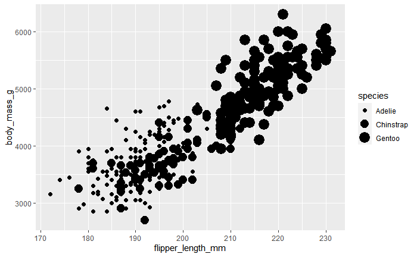